# Jeremy D Harris, PhD

[Here is my CV](https://github.com/Jeremy-D-Harris/cv_jdh_2022/blob/main/CV_JDH_Feb2023.pdf)

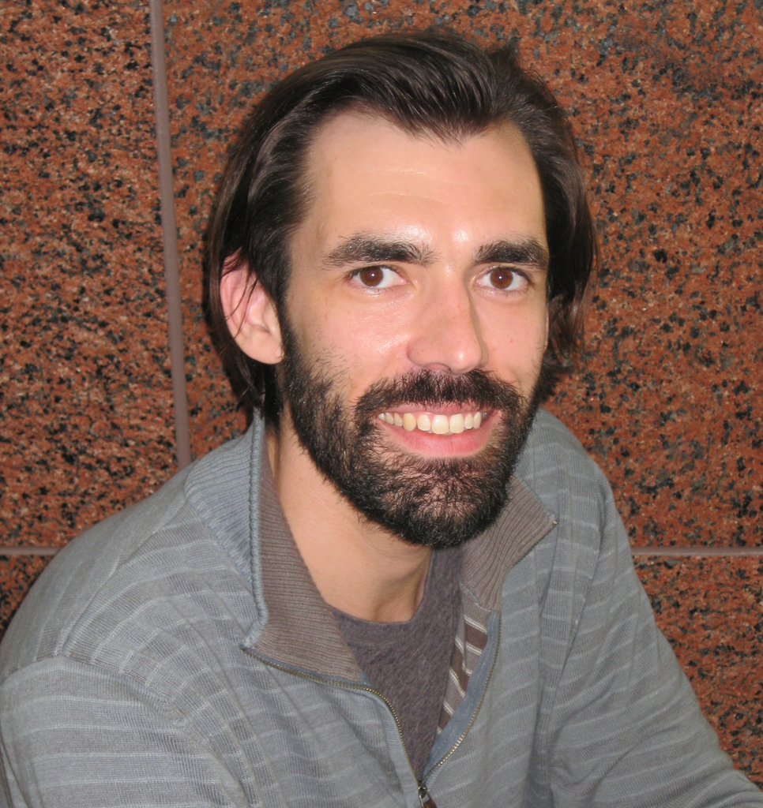

Research Scientist II, [Weitz Lab](https://weitzgroup.biosci.gatech.edu/)  
Biological Sciences  
Georgia Tech, Atlanta, GA

## About

Broadly, I use math models to study biological systems. In my PhD, I studied spatiotemporal patterns in neural firing rate models, advised by [Professor Bard Ermentrout](https://sites.pitt.edu/~phase/). During my postdoc’ing, I transitioned to studying virus-host dynamics across scales & systems.

I am currently in the [Weitz lab](https://weitzgroup.biosci.gatech.edu/) at GA Tech in biological sciences. I did my first postdoc in biology at Emory University, supervised by [Professor Katia Koelle](https://scholarblogs.emory.edu/koellelab/group-members/) (2017-2020) after receiving my PhD in applied math at University of Pittsburgh (2017).

#### Weblinks

- [Here is my github - trying to use actively!](https://github.com/Jeremy-D-Harris/)
- [linkedin page - not using actively :(](https://www.linkedin.com/in/jeremy-d-harris)
- [orcid](https://orcid.org/0000-0002-6836-3620)

## Research

I use math models to study the ecology and evolution of infectious diseases. Infectious diseases occur often occur across multiple scales. For instance, in epidemics models there is the individual level, where transmission is often quantified by the reproduction number, $R_0$ (“strength”) and the population level, where transmission is quantifed by the observed exponential growth rate of new cases, “$r$” (“speed”). Hence, models can be used to bridge these scales, telling us about *hidden variables* from those observed.

#### Weitz Lab (2020-Present)

- **epidemic models**
  - asymptomatic transmission in COVID-19 using a generation interval framework
  - effects of variation in transmissibility and susceptibility
- **virus-microbe dynamics and entanglement**
  - latent period variability in one-step experiments
  - multiple phages form lysogens on a shared host $\rightarrow$ complex population dynamics
  - cellular responses to different bulk MOI $\rightarrow$ varying infection outcomes, e.g., lysis inhibition, pseudolysogeny

#### Koelle lab (2017-2020)

- cellular responses to multiple infections in influenza
- emergent population dynamics

#### Recent Publications

- Harris, J. D.* , Park, S. W.*, Dushoff, J., & Weitz, J. S. (2023). How time-scale differences in asymptomatic and symptomatic transmission shape SARS-CoV-2 outbreak dynamics. Epidemics, 100664. [DOI](https://doi.org/10.1016/j.epidem.2022.100664)
- Martin, B. E.* , Harris, J. D.*, Sun, J., Koelle, K., & Brooke, C. B. (2020). Cellular co-infection can modulate the efficiency of influenza A virus production and shape the interferon response. PLoS pathogens, 16(10), e1008974. [DOI](https://doi.org/10.1371/journal.ppat.1008974)

*these folks contributed equally

## Teaching

- [QBioS Foundations Course](https://qbios.gatech.edu/course-information) (Fall 2021 & 2022)  
  Modules taught:
  - organismal behavior & sensing
  - excitability: neurons
  - excitability: cardiac cells
  - biomechanics of movement
- [ICTP-SAIFR Training Program in Quantitative Biology and Ecology](https://www.ictp-saifr.org/qbioprogram/) (Summer 2022) Module taught:
  - organismal behavior & sensing